# Markov chain Monte Carlo sampling algorithms

# Stochastic gradient Langevin dynamics (SGLD)

- Without the costly Metropolis–Hastings step, we can also save further by approximating $\nabla\log\pi$
- Imagine $\pi$ is of the form
  $$\pi(\theta|y) \propto \prod_i f(y_i|\theta) \pi_0(\theta)$$
- **Question.** If $y_i$ are data points, what kind of assumption are we making about them?
- If this is the case then
  $$\nabla\log\pi(\theta|y) = \nabla\log\pi_0(\theta) + \sum_{i=1}^n
  \nabla\log f(y_i|\theta)$$
- This computation is $O(n)$. We can approximate through **subsampling**
  - Sample $N \ll n$ integers between $1$ and $n$, store as the set $I_N$ (with $|I_N| = N$)
  - Approximate gradient with
    $$\nabla\log\pi_0(\theta) + \frac{n}{N} \sum_{j \in I_N} \nabla\log
    f(y_j|\theta)$$
- **Question.** What is the new computational cost?

# Remarks on SGLD

- Can be implemented with either fixed or decreasing step-size (fixed more common, simpler to analyse)
- Often $N = cn$ size subsample is needed to guarantee efficient sampling, which is a negative
  - But the constant $c$ matters and is often small
  - further improvements can be made using *control variates* (I will not cover this)
  - see Welling & Teh (2011) or Nemeth & Fearnhead (2021) for more
- SGLD is popular in machine learning, particularly Bayesian deep learning
- Generally useful in the ‘tall data scenario’ ($n \gg d$), which is not always interesting statistically
  - Posterior often looks Gaussian (Bernstein–Von Mises), see Bardenet et al (2017)
  - Lots of data per parameter

# Part 3: Parallel Tempering + adaptive MCMC

- There are many more elaborate and exciting MCMC algorithms
- I will explain one, parallel tempering, and then one technique to automate tuning

# Multi-modal target distributions

- Gradient-based methods do not typically work well if the target distribution has a multi-modal density
  - **Question.** Why do you think this is?
- In this instance many alternative strategies are based on *tempering* the target
  $$\pi(x) \to \pi(x)^\beta$$
  for some $\beta < 1$
- The name comes from tempering metal (heating it up so it’s easier to work with)
- $1/\beta$ is called the temperature, so $\beta < 1 \implies$ heating up the target
- This typically reduces the level of multi-modality

# Tempering example

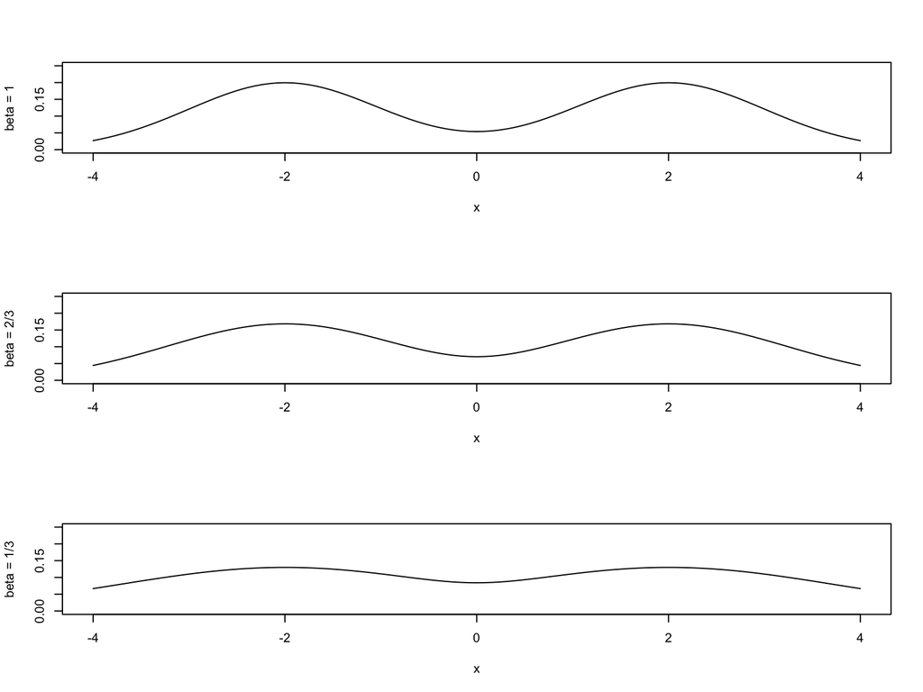

# Tempering algorithms

- There are many ways to take this idea and use it to create sampling/optimisation algorithms
  - Simulated annealing (optimisation)
  - Simulated tempering (sampling)
  - Parallel tempering (sampling)
- We will focus on the last of these
- Parallel tempering algorithm:
  - Create $K$ parallel Markov chains each targeting $\pi^{\beta_k}$ for some $\beta_k$, $1 \leq k \leq K$
  - At pre-specified intervals propose **swaps** between adjacent chains
  - In the hotter chains travel between modes is easier, and then states swap with the cooler chains

# Example: mixture of 2 Gaussians, means 8 and -8

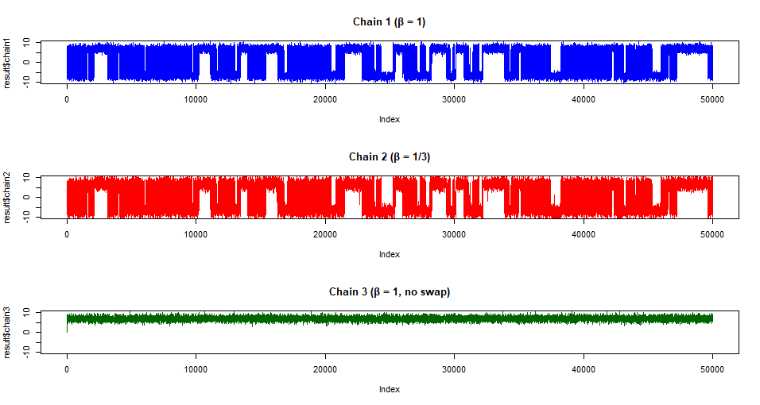

# Algorithm design for tempering - natural questions

- How many parallel chains?
- At what temperatures should they be set?
- How often should swaps be proposed?
- What proportion of swaps should be accepted?

# Adaptive MCMC - Motivation

- One reason that the Gibbs sampler remains popular is that there are no tuning parameters
- E.g. in the Random Walk Metropolis
  $$Y \sim N(x, h^2 I)$$
  we must choose a step-size $h$
- Often there are many more parameters to choose (e.g. preconditioning matrix $\Sigma \in \mathbb{R}^{d \times d}$)
- It can be hard to find a good choice (through e.g. pilot runs/mathematical calculations)
- But good choices are *crucial* to algorithm performance
- **Adaptive MCMC is an attempt to solve this issue**

# Adaptive MCMC - basic idea

- In adaptive MCMC we try to learn good choices for tuning parameters ‘on-the-fly’
  1. Start with an arbitrary choice
  2. Run the algorithm for $k$ iterations
  3. Check some statistics and update our choices accordingly
  4. Repeat until sufficiently good choices are found

# A very simple adaptive MCMC algorithm

- Take the simple 1D random walk Metropolis, with proposal
  $$Y \sim N(x, h^2)$$
- We might want to choose $h$ s.t. $\mathbb{E}[\alpha] \approx 0.44$
- So we can do the following:
  1. Start with $h = h_0$
  2. Run algorithm for $k=100$ (say) iterations
  3. Calculate the average acceptance rate
  4. Adapt $h$ based on how far this is from 0.44
  5. Repeat until some criterion is met (e.g. close to 0.44, max iterations etc.)
- **Question.** If the average acceptance rate is **larger** than 0.44, should we increase or decrease $h$?

# Code for the simple adaptive MCMC algorithm

```r
RWM_output <- RWM(logpi = logpi_gauss,
                    nits = adapt_iter,
                    h = h[k],
                    x_curr = start_x[k])

av_accept[k] <- RWM_output$a_rate

# update h based on average_accept_rate
if (av_accept[k] > 0.5) {
  h[k+1] <- h[k] * 1.2
} else if (av_accept[k] < 0.4) {
  h[k+1] <- h[k] * 0.8
} else {
  h[k+1] <- h[k]
}
```

# Results for the simple adaptive MCMC algorithm

```
## Epoch:  1 h =  100 Average acceptace rate:  0.03
## Epoch:  2 h =  80 Average acceptace rate:  0.01
## Epoch:  3 h =  64 Average acceptace rate:  0.02
## Epoch:  4 h =  51.2 Average acceptace rate:  0.02
## Epoch:  5 h =  40.96 Average acceptace rate:  0.03
## Epoch:  6 h =  32.768 Average acceptace rate:  0.01
## Epoch:  7 h =  26.2144 Average acceptace rate:  0.04
## Epoch:  8 h =  20.97152 Average acceptace rate:  0.05
## Epoch:  9 h =  16.77722 Average acceptace rate:  0.06
## Epoch:  10 h =  13.42177 Average acceptace rate:  0.1
## Epoch:  11 h =  10.73742 Average acceptace rate:  0.15
## Epoch:  12 h =  8.589935 Average acceptace rate:  0.12
## Epoch:  13 h =  6.871948 Average acceptace rate:  0.18
## Epoch:  14 h =  5.497558 Average acceptace rate:  0.23
## Epoch:  15 h =  4.398047 Average acceptace rate:  0.25
## Epoch:  16 h =  3.518437 Average acceptace rate:  0.35
## Epoch:  17 h =  2.81475 Average acceptace rate:  0.32
## Epoch:  18 h =  2.2518 Average acceptace rate:  0.48
## Epoch:  19 h =  2.2518 Average acceptace rate:  0.44
## Epoch:  20 h =  2.2518 Average acceptace rate:  0.37
```

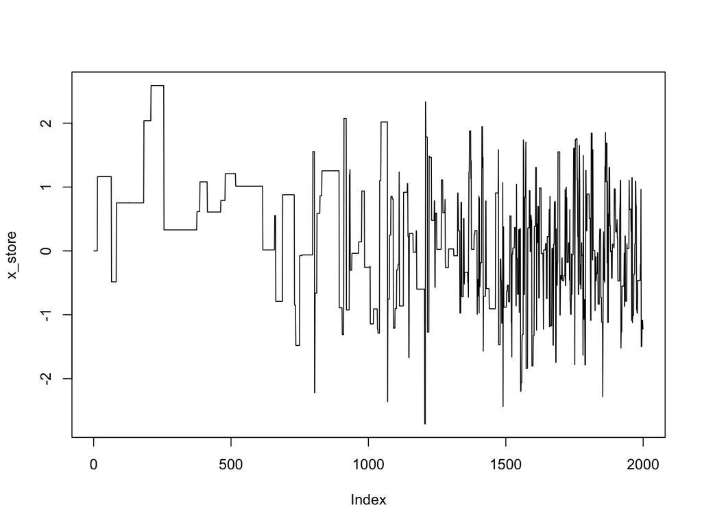

# A word of caution about adaptation

- Naively adapting the tuning parameters of the Markov kernel is dangerous
  - We are no longer dealing with a time-homogeneous chain (the kernel changes each iteration)
  - The way the kernel changes depends on the past (may no longer be Markov)
- To prove results about adaptive MCMC is therefore challenging
- In practice the simplest way of avoiding issues is to (safely) adapt during Burn in, and then stop
- I just gave a very simple way of adapting, there are far more sophisticated approaches (that I will not cover)
- Also lots of open theoretical questions in the area (e.g. which adaptive schemes are better?)

# Some further MCMC algorithms that I didn’t mention

- Reversible jump MCMC
  - sampling between different spaces of models
  - aim to choose the best one or average over them
- Pseudo-marginal MCMC
  - Running an exact MCMC algorithm when the likelihood is intractable
  - Typically relies on importance sampling to unbiasedly estimate likelihoods
- Interacting particle systems (e.g. Stein variational gradient descent)
  - Evolving several particles along a ‘gradient flow’ to reach a particle approximation to $\pi$
- Non-reversible algorithms
  - E.g. piece-wise deterministic Markov processes, which can be exactly simulated in continuous-time

# End of module - Do zobaczenia!

I hope you enjoyed the course and am happy to answer any further questions over e-mail!

# Appendix: Case studies

- I will look at two case examples of MCMC in practice
  - Bayesian Variable selection for genomic data analysis
  - Generalised linear spatial models for radioactivity on a pacific island

# Case Study 1: Bayesian Variable Selection

# The Variable selection problem

- A very famous problem in probabilistic modelling
- Given data $(y_i,x_{i1},...,x_{ip})_{i=1}^n$, which of the covariates ($x$’s) should I use to predict $y$?
- We will consider the setting of linear regression here

# Solution 1: Choose the best model

- We can use many heuristic model selection procedures
  - forward selection
  - backwards elimination
- We can also use more modern penalized approaches
  - e.g. LASSO
- These approaches will choose the *single best model* for the data
- If there are two correlated covariates, it will typically choose one
  - **Question.** What do we call two correlated covariates in linear regression?
- This is suboptimal if our primary interest is in learning which covariates *might* be associated with the response

# Example: genomic data

- A typical genomic dataset contains the covariates relating to many different genes in the body
- The response might be whether someone has a disease, or some continuous value that is higher if people have a disease than not (e.g. blood pressure, testosterone etc.)
- Scientists want to know all the genes that might be associated with the disease, so that they can investigate those genes further
- Typically the number of possible genes (number of predictors $p$) is much larger than the sample size $n$
- This setting is known as *high-dimensional* statistics

# Bayesian variable selection via MCMC

- Introduce $\gamma = \{0,1\}^p$, where
  $$\gamma_j = 1 \implies \beta_j \neq 0$$
- This controls whether the $j$th covariate is included in the model
- The full linear regression model is now:
  $$y_i = \alpha + \beta_1 \gamma_1 x_{i1} + ... + \beta_p\gamma_p x_{ip} +
  \epsilon_i$$
- Each particular value for $\gamma$ is associated with a particular model $M_\gamma$
  - **Question.** If only $\gamma_1$ and $\gamma_p$ are not zero, what is model $M_\gamma$?

# Choice of prior distribution

- We will make the problem easier and choose **conjugate priors** where we can
- Conditional on a certain value for $\gamma$, we can choose priors for $\beta$, $\alpha$ and $\sigma^2$ such that $\pi(\beta, \sigma^2, \alpha|y, X, \gamma)$ is tractable
- These can also be chosen in such a way that the marginal posterior $\pi(\gamma|y,X)$ can be computed
- Note: this cannot be done in general, only for linear regression

# Example prior specification

- One example is called the *g*-prior. Gives marginal posterior (for positive real $g$)
  $$\pi(\gamma|y,X) \propto \pi_0(\gamma)
  \frac{(1+g)^{\frac{n-p_\gamma-1}{2}}}{(1+g(1-R_\gamma^2))^{\frac{n-1}{2}}}$$
- **Question.** What do you think $R_\gamma^2$ is?
- **Question.** What do you think $p_\gamma$ is?

# MCMC over $\gamma$ space

- Our task is now to perform MCMC over the space $\{0,1\}^p$
- **Question.** Mathematically, what is this space?
- We will introduce a form of ‘add-delete-swap sampler’ for this

# Add-Delete-Swap sampler

At each iteration, given current state $\gamma \in \{0,1\}^p$, do the following:

1. Decide whether to ADD/DELETE w.p. $\lambda$ or SWAP w.p. $1-\lambda$
2. First set proposal $\gamma^* = \gamma$. Then do the following
   1. If ADD/DELETE, draw $j \sim \mathcal{U}[{1,...,p}]$ and set $\gamma^*_j = 1-\gamma_j$
   2. If SWAP, choose a $j$ for which $\gamma^*_j = 1$ and a $k$ for which $\gamma^*_k = 0$ and swap them (both choices uniform)
3. Set the next state to be $\gamma^*$ with probability $\alpha(\gamma, \gamma^*)$, otherwise set it to be $\gamma$, where
   $$\alpha(\gamma,\gamma^*) = \min \left( 1,
   \frac{\pi(\gamma^*|y,X)}{\pi(\gamma|y,X)} \right).$$
- **Question.** Why do I only need a Metropolis step here, not full Metropolis–Hastings with the $q(\gamma^*,\gamma)/q(\gamma,\gamma^*)$ part?

# Some remarks

- The SWAP move is important for mixing when dealing with correlated predictors
- This sampler isn’t fool proof and developing alternatives is an active research area

# One useful posterior summary

- The posterior inclusion probability (or PIP) for predictor $j$ is
  $$\mathbb{P}_\pi(\gamma_j = 1|y, X)$$
- This tells us the posterior probability that covariate $j$ should be included in the model
- Any PIP significantly bigger than 0 might be of interest

# Examples

- [See page 178-183 here](https://link.springer.com/content/pdf/10.1007/s11222-011-9299-z.pdf)

# Case study 2: GLSMs for radioactivity estimation

# Generalised Linear Spatial Models (GLSMs)

- Consider observations $(y_i,z_i,x_i)$
  - $y_i$ treated as realisations of $Y_i$ following some exponential family distribution
  - $z_i$ spatial location (e.g. in $\mathbb{R}^2$) associated with sample $i$
  - $x_i$ other covariates associated with sample $i$
- Generalised linear spatial model (GLSM) takes the form
  $$h(\mathbb{E}[Y_i|S(z_i)]) = S(z_i) + x_i^T\beta,$$
  for some link function $h$
- $(S(z))_{z \in \mathbb{R}^2}$ is some unknown function defined over $z$-space. Represents some latent intensity field
- Interest is usually in some expectations from the posterior
  $$\pi(S(z)|y,x)$$

# Radioactivity at Rongelap island

- Rongelap Island forms part of the Republic of the Marshall Islands
- Located in the Pacific Ocean ~2500 miles from Hawaii
- Experienced contamination following Bikini Atoll nuclear weapons testing programme in 1950s
- Former inhabitants lived in self-imposed exile on neighbouring island since 1985.
- Marshall Islands National Radiological Survey has examined the current levels of contamination by counting photon emissions at $n=157$ locations over the island.
- Good reasons to model data as **Poisson counts with spatial correlation**

# The Marshall Islands (from Encyclopedia Brittanica)

[figure not shown]

# The dataset (Diggle, Tawn & Moyeed, 1997)

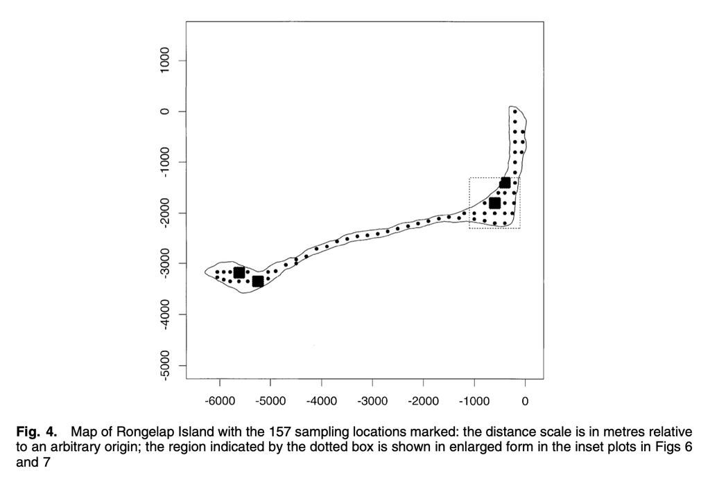

# The Posterior

- The model here is
  $$Y_i |S(z_i) \sim \text{Poisson} (e^{S(z_i)})$$
- The prior on the spatial intensity field $S(z)$ is a Gaussian process, which means
  $$S(z_i) \sim N(0,\sigma^2), \qquad \text{Cov}(S(z_i),S(z_j)) =
  \sigma^2\exp\left\{\phi^{-1}\|z_i - z_j\|^2 \right\}$$
- The parameters $\sigma^2$ and $\phi$ will also have a hyperprior $\pi_0(\sigma^2,\phi)$
- Posterior for $(S(z_1),S(z_2),...,S(z_n),\sigma,\phi)|y$ is therefore 159-dimensional and quite complicated!

# MCMC strategy

- Common to use a blocking strategy, alternating
  $$(\sigma^2,\phi)|S,y, \qquad S|(\sigma^2,\phi,y)$$
- Use something like MALA to update $S|(\sigma^2,\phi,y)$ (high-dimensional, smooth)
- Same can be used for $(\sigma^2,\phi)|S,y$, or something more bespoke (low-dimensional, more irregular)

# The mean posterior intensity field (Diggle, Tawn & Moyeed, 1997)

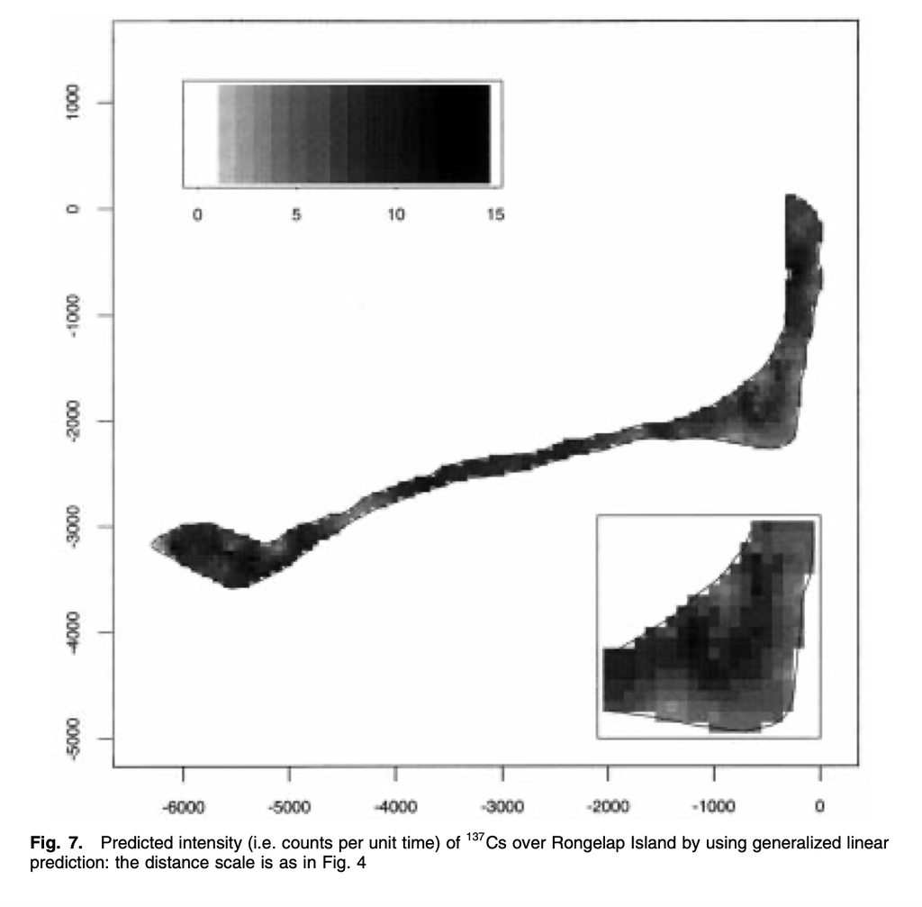

# Areas of with high probability of high contamination (Diggle, Tawn & Moyeed, 1997)

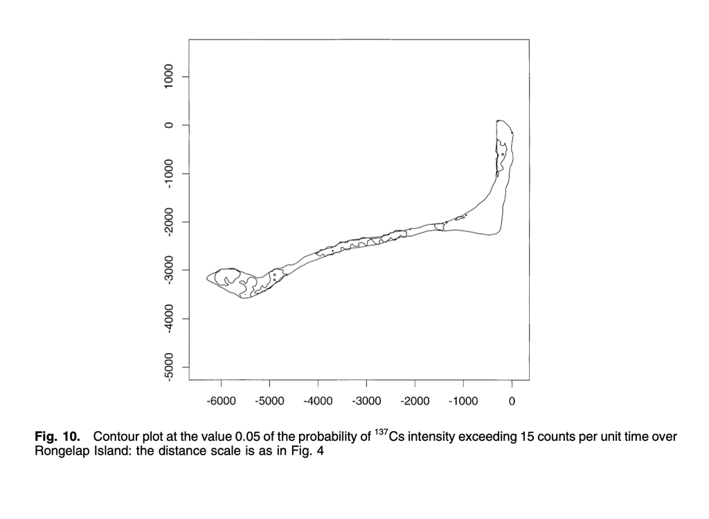